# КИЇВСЬКИЙ НАЦІОНАЛЬНИЙ УНІВЕРСИТЕТ

ІМЕНІ ТАРАСА ШЕВЧЕНКА

## Факультет комп'ютерних наук та кібернетики

### Звіт до практичної роботи №1

**з дисципліни «Інтелектуальна обробка даних»**

**Варіант №8**

**Виконав:** студент 4-го курсу  
**Група:** ТК-41  
**ПІБ:** Луковський Максим

**Київ – 2025**

# Попередній аналіз

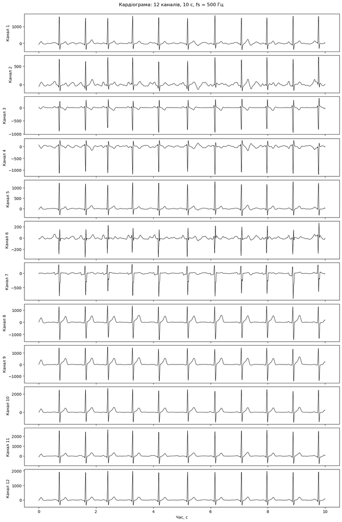

```python
%matplotlib inline
import numpy as np
import matplotlib.pyplot as plt


fs = 500
dt = 1.0 / fs
num_channels = 12


data = np.loadtxt('A8.txt', delimiter=',')
N = data.shape[0]


t = np.arange(N) * dt


fig, axes = plt.subplots(num_channels, 1, figsize=(12, 18), sharex=True, constrained_layout=True)
for ch in range(num_channels):
    axes[ch].plot(t, data[:, ch], lw=0.8, color='black')
    axes[ch].set_ylabel(f'Канал {ch+1}')

axes[-1].set_xlabel('Час, с')
fig.suptitle('Кардіограма: 12 каналів, 10 с, fs = 500 Гц', y=1.02)
plt.show()
```

```python
# Обчислення статистик для кожного каналу
import math

EPS = 1e-12

def harmonic_mean_any(x: np.ndarray) -> float:
    n = x.size
    inv_sum = np.sum(1.0 / (np.abs(x) + EPS))
    return n / inv_sum

def geometric_mean_any(x: np.ndarray) -> float:
    logs = np.log(np.abs(x) + EPS)
    return float(np.exp(np.mean(logs)))

def gini_mean_difference(x: np.ndarray) -> float:
    # GMD = (2/(n*(n-1))) * sum_{i=1..n} (2i-n-1) * x_(i) for sorted x
    x_sorted = np.sort(x)
    n = x_sorted.size
    idx = np.arange(1, n + 1)
    coef = (2 * idx - n - 1)
    return (2.0 / (n * (n - 1))) * np.sum(coef * x_sorted)

def sample_moments_skew_kurt(x: np.ndarray):
    m = np.mean(x)
    s2 = np.var(x, ddof=0)
    s = np.sqrt(s2)
    m3 = np.mean((x - m) ** 3)
    m4 = np.mean((x - m) ** 4)
    skew = m3 / (s ** 3 + EPS)
    kurt_excess = m4 / (s ** 4 + EPS) - 3.0
    return m, s2, skew, kurt_excess

def hist_mode_bin_center(x: np.ndarray, bins: int = 50) -> float:
    counts, edges = np.histogram(x, bins=bins)
    k = np.argmax(counts)
    return float(0.5 * (edges[k] + edges[k + 1]))

stats = []
for ch in range(num_channels):
    x = data[:, ch]
    mean = float(np.mean(x))
    hmean = float(harmonic_mean_any(x))
    gmean = float(geometric_mean_any(x))
    var = float(np.var(x, ddof=0))
    gmd = float(gini_mean_difference(x))
    mode_est = float(hist_mode_bin_center(x))
    median = float(np.median(x))
    _, _, skew, kurt_ex = sample_moments_skew_kurt(x)
    stats.append({
        'Канал': ch + 1,
        'Середнє': mean,
        'Середнє гармонічне': hmean,
        'Середнє геометричне': gmean,
        'Дисперсія': var,
        'Середня різниця Джині': gmd,
        'Мода (оцінка)': mode_est,
        'Медіана': median,
        'Коеф. асиметрії': float(skew),
        'Коеф. ексцесу': float(kurt_ex),
    })

# Вивід таблиці статистик
import pandas as pd
stats_df = pd.DataFrame(stats)
stats_df
```

|  | Канал | Середнє | Середнє гармонічне | Середнє геометричне | Дисперсія | Середня різниця Джині | Мода (оцінка) | Медіана | Коеф. асиметрії | Коеф. ексцесу |
| --- | --- | --- | --- | --- | --- | --- | --- | --- | --- | --- |
| 0 | 1 | 34.458220 | 6.186486 | 28.338914 | 45373.331449 | 131.325190 | -1.7544 | -2.739650 | 5.130575 | 29.739199 |
| 1 | 2 | 14.062620 | 5.339851 | 22.729249 | 9378.528842 | 72.749180 | -23.5438 | -2.083550 | 4.512706 | 26.124456 |
| 2 | 3 | -24.788961 | 0.339462 | 7.132020 | 17442.014500 | 76.087592 | 3.9032 | -1.200750 | -4.765833 | 25.735221 |
| 3 | 4 | -23.107090 | 2.879259 | 25.393002 | 23017.755743 | 99.116886 | 15.2361 | 2.884250 | -5.101131 | 30.163209 |
| 4 | 5 | 31.253666 | 2.159153 | 17.089433 | 29150.601308 | 101.147103 | 1.3007 | -0.919310 | 5.039695 | 28.385225 |
| 5 | 6 | -1.564069 | 3.388216 | 11.376830 | 1931.233219 | 35.429208 | -5.7020 | -2.894950 | -2.405672 | 19.949209 |
| 6 | 7 | -16.319648 | 3.788969 | 12.921332 | 11755.193812 | 71.067915 | -8.0688 | -0.160125 | -3.890394 | 22.508963 |
| 7 | 8 | 47.400926 | 2.856823 | 30.434936 | 86317.200472 | 241.770777 | -14.3820 | -2.228450 | -0.807393 | 9.023544 |
| 8 | 9 | 65.224116 | 3.141437 | 28.884497 | 92381.689804 | 252.107667 | 5.9930 | 0.555200 | -0.257638 | 8.822818 |
| 9 | 10 | 90.663828 | 2.940393 | 28.453199 | 130664.397951 | 256.597461 | -37.2150 | -0.194785 | 3.382749 | 19.432497 |
| 10 | 11 | 65.849958 | 6.595411 | 30.258871 | 116264.879847 | 212.271554 | 6.7844 | -2.519750 | 4.815383 | 28.797834 |
| 11 | 12 | 51.424001 | 2.731813 | 17.237733 | 63721.100734 | 142.628309 | -9.0255 | -1.716200 | 5.439000 | 32.621567 |

## Аналіз розподілів амплітуд

Гістограми показують розподіл амплітуд для кожного з 12 каналів ЕКГ:

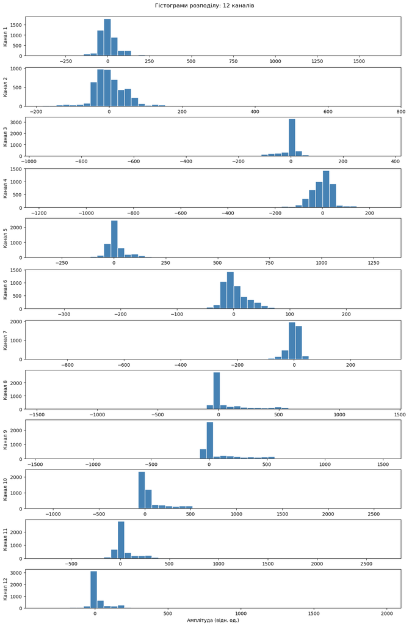

```python
fig, axes = plt.subplots(num_channels, 1, figsize=(12, 18), sharex=False, constrained_layout=True)
for ch in range(num_channels):
    x = data[:, ch]
    axes[ch].hist(x, bins=50, color='steelblue', edgecolor='white')
    axes[ch].set_ylabel(f'Канал {ch+1}')
axes[-1].set_xlabel('Амплітуда (відн. од.)')
fig.suptitle('Гістограми розподілу: 12 каналів', y=1.02)
plt.show()
```

## Перевірка гіпотези про нормальний розподіл

У таблиці наведено результати статистичних тестів для перевірки нормальності розподілу по кожному каналу:

**Використані тести:**

- **Тест Шапіро-Уїлка** - найпотужніший тест для малих вибірок (n < 5000)

**Інтерпретація p-value:**

- **p > 0.05** - немає підстав відхилити гіпотезу про нормальність (розподіл близький до нормального)
- **p ≤ 0.05** - гіпотеза про нормальність відхиляється (розподіл значно відрізняється від нормального)

```python
# Перевірка нормальності: тест Шапіро-Уїлка
from scipy import stats

normality = []
for ch in range(num_channels):
    x = data[:, ch]
    stat_sh, p_sh = stats.shapiro(x)
    normality.append({'Канал': ch+1, 'Шапіро p': float(p_sh)})

normality_df = pd.DataFrame(normality)
normality_df
```

|  | Канал | Шапіро p |
| --- | --- | --- |
| 0 | 1 | 2.947400e-83 |
| 1 | 2 | 3.231933e-77 |
| 2 | 3 | 1.797420e-84 |
| 3 | 4 | 6.640499e-82 |
| 4 | 5 | 4.565447e-84 |
| 5 | 6 | 5.007760e-72 |
| 6 | 7 | 1.225939e-80 |
| 7 | 8 | 2.275929e-70 |
| 8 | 9 | 5.231256e-70 |
| 9 | 10 | 3.249627e-78 |
| 10 | 11 | 1.451480e-82 |
| 11 | 12 | 3.615649e-85 |

Висновок - Для всіх каналів гіпотеза про нормальний розподіл відхиляється.

## Нормалізація даних

У таблиці наведено результати нормалізації даних по кожному каналу:

**Процес нормалізації:**

- **Формула:** Z = (X - μ) / σ, де μ - середнє, σ - стандартне відхилення
- **Мета:** приведення всіх каналів до однакового масштабу для порівняння
- **Результат:** математичне сподівання = 0, дисперсія = 1

**Перевірка якості нормалізації:**

- **Середнє після нормалізації** повинно бути близьким до 0 (в межах похибки обчислень)
- **Дисперсія після нормалізації** повинна дорівнювати 1.0
- **Точність:** значення округлені до 6 знаків після коми

**Значення нормалізації:**

- Усуває вплив різних масштабів амплітуд між каналами
- Дозволяє порівнювати канали між собою
- Підготовлює дані для подальшого статистичного аналізу
- Забезпечує стабільність обчислень при використанні різних алгоритмів

```python
means = np.mean(data, axis=0)
stds = np.std(data, axis=0, ddof=0)


stds_safe = np.where(stds == 0.0, 1.0, stds)

Z = (data - means) / stds_safe


check_df = pd.DataFrame({
    'Канал': np.arange(1, num_channels+1),
    'Середнє після': np.round(np.mean(Z, axis=0), 6),
    'Дисперсія після': np.round(np.var(Z, axis=0, ddof=0), 6)
})
check_df
```

|  | Канал | Середнє після | Дисперсія після |
| --- | --- | --- | --- |
| 0 | 1 | -0.0 | 1.0 |
| 1 | 2 | -0.0 | 1.0 |
| 2 | 3 | 0.0 | 1.0 |
| 3 | 4 | -0.0 | 1.0 |
| 4 | 5 | -0.0 | 1.0 |
| 5 | 6 | 0.0 | 1.0 |
| 6 | 7 | -0.0 | 1.0 |
| 7 | 8 | 0.0 | 1.0 |
| 8 | 9 | -0.0 | 1.0 |
| 9 | 10 | 0.0 | 1.0 |
| 10 | 11 | 0.0 | 1.0 |
| 11 | 12 | 0.0 | 1.0 |

## Обчислення модуля сигналу

```python
module_signal = np.sqrt(np.sum(data ** 2, axis=1))
len(module_signal), module_signal[:5]
```

```
(5000,
 array([162.62371066, 160.53824627, 157.27298554, 152.23322736,
        146.01414124]))
```

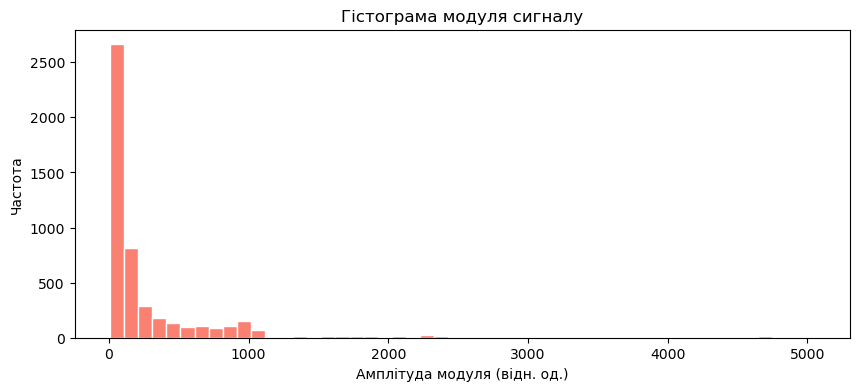

|  | Середнє | Середнє гармонічне | Середнє геометричне | Дисперсія | Середня різниця Джині | Мода (оцінка) | Медіана | Коеф. асиметрії | Коеф. ексцесу |
| --- | --- | --- | --- | --- | --- | --- | --- | --- | --- |
| 0 | 364.576622 | 76.288169 | 138.769183 | 519962.546993 | 506.934089 | 57.965074 | 101.503561 | 3.978345 | 17.888252 |

```python
x = module_signal

mod_stats = {
    'Середнє': float(np.mean(x)),
    'Середнє гармонічне': float(harmonic_mean_any(x)),
    'Середнє геометричне': float(geometric_mean_any(x)),
    'Дисперсія': float(np.var(x, ddof=0)),
    'Середня різниця Джині': float(gini_mean_difference(x)),
    'Мода (оцінка)': float(hist_mode_bin_center(x)),
    'Медіана': float(np.median(x)),
    'Коеф. асиметрії': float(sample_moments_skew_kurt(x)[2]),
    'Коеф. ексцесу': float(sample_moments_skew_kurt(x)[3]),
}
mod_stats_df = pd.DataFrame([mod_stats])

fig, ax = plt.subplots(1, 1, figsize=(10, 4))
ax.hist(x, bins=50, color='salmon', edgecolor='white')
ax.set_xlabel('Амплітуда модуля (відн. од.)')
ax.set_ylabel('Частота')
ax.set_title('Гістограма модуля сигналу')
plt.show()

mod_stats_df
```

# Однофакторний дисперсійний аналіз.

## Аналіз результатів однофакторного дисперсійного аналізу

**Мета аналізу:** Перевірити, чи є вимірювання по 12 каналах ЕКГ результатами різних рівнів одного фактору.

```python
k = 12  # кількість каналів (рівнів фактора A)
n = N   # кількість спостережень у кожному каналі (5000)

# Крок 1: Дисперсія для кожного рівня S²ᵢ
S2_i = np.zeros(k)
x_bar_i = np.zeros(k)  # середнє для кожного каналу

for i in range(k):
    x_ij = data[:, i]
    x_bar_i[i] = np.mean(x_ij)
    S2_i[i] = (1/(n-1)) * np.sum((x_ij - x_bar_i[i])**2)

# Крок 2: Перевірка рівності дисперсій (тест Левена)
from scipy.stats import levene
levene_stat, levene_p = levene(*[data[:, i] for i in range(k)])
print(f"Тест Левена: статистика = {levene_stat:.4f}, p-value = {levene_p:.6f}")
print(f"Дисперсії {'рівні' if levene_p > 0.05 else 'НЕ рівні'} (α=0.05)\n")

# Крок 3: Оцінка дисперсії поза впливом фактора S²₀
S2_0 = (1/k) * np.sum(S2_i)

# Крок 4: Загальна дисперсія всіх спостережень S²
all_data = data.flatten()
x_bar = np.mean(all_data)
S2 = (1/(k*n - 1)) * (np.sum(data**2) - (1/(k*n)) * (np.sum(data))**2)

# Крок 5: Дисперсія, зумовлена фактором S²ₐ
S2_A = (n/(k-1)) * np.sum((x_bar_i - x_bar)**2)

# Крок 6: F-статистика
F_stat = S2_A / S2_0
f1 = k - 1
f2 = k * (n - 1)

# Крок 7: Критичне значення і p-value
from scipy.stats import f as f_dist
alpha = 0.05
F_crit = f_dist.ppf(1 - alpha, f1, f2)
p_value = 1 - f_dist.cdf(F_stat, f1, f2)

# Вивід результатів
print("="*60)
print("РЕЗУЛЬТАТИ ОДНОФАКТОРНОГО ДИСПЕРСІЙНОГО АНАЛІЗУ")
print("="*60)
print(f"Кількість рівнів фактора (каналів): k = {k}")
print(f"Кількість спостережень у рівні: n = {n}")
print(f"\nДисперсії по каналах S²ᵢ:")
for i in range(k):
    print(f"  Канал {i+1}: {S2_i[i]:.4f}")
print(f"\nS²₀ (поза впливом фактора) = {S2_0:.4f}")
print(f"S² (загальна) = {S2:.4f}")
print(f"S²ₐ (зумовлена фактором) = {S2_A:.4f}")
print(f"\nF-статистика = {F_stat:.4f}")
print(f"Степені свободи: f₁ = {f1}, f₂ = {f2}")
print(f"F_критичне (α={alpha}) = {F_crit:.4f}")
print(f"p-value = {p_value:.6e}")
print(f"\nВисновок: Вплив фактора {'ЗНАЧУЩИЙ' if F_stat > F_crit else 'НЕ значущий'} (α={alpha})")
print("="*60)
```

```
Тест Левена: статистика = 234.3658, p-value = 0.000000
Дисперсії НЕ рівні (α=0.05)

============================================================
РЕЗУЛЬТАТИ ОДНОФАКТОРНОГО ДИСПЕРСІЙНОГО АНАЛІЗУ
============================================================
Кількість рівнів фактора (каналів): k = 12
Кількість спостережень у рівні: n = 5000

Дисперсії по каналах S²ᵢ:
  Канал 1: 45382.4079
  Канал 2: 9380.4049
  Канал 3: 17445.5036
  Канал 4: 23022.3602
  Канал 5: 29156.4326
  Канал 6: 1931.6195
  Канал 7: 11757.5453
  Канал 8: 86334.4674
  Канал 9: 92400.1698
  Канал 10: 130690.5361
  Канал 11: 116288.1375
  Канал 12: 63733.8475

S²₀ (поза впливом фактора) = 52293.6194
S² (загальна) = 53630.1658
S²ₐ (зумовлена фактором) = 7342425.3674

F-статистика = 140.4077
Степені свободи: f₁ = 11, f₂ = 59988
F_критичне (α=0.05) = 1.7888
p-value = 1.110223e-16

Висновок: Вплив фактора ЗНАЧУЩИЙ (α=0.05)
============================================================
```

# Двофакторний аналіз.

```python
import numpy as np
import pandas as pd
from scipy.stats import f as f_dist

# === Параметри експерименту ===
k = 12   # кількість каналів (фактор A)
m = 5    # кількість часових відрізків (фактор B)
n = 1000 # кількість спостережень у клітинці

# data: масив (5000, 12) = 5*1000 × 12
# перетворюємо у (k, m, n)
data_3d = data[:m*n, :].reshape(m, n, k).transpose(2, 0, 1)  # (12, 5, 1000)

# Середні у клітинках
x_ij = np.mean(data_3d, axis=2)   # (k, m)

# === Варіант 1. Незалежні фактори (за методичкою з Q1..Q4) ===

# Сирі суми
Xi_raw = data_3d.sum(axis=(1, 2))   # Σ по j,r для кожного i (k,)
Xj_raw = data_3d.sum(axis=(0, 2))   # Σ по i,r для кожного j (m,)
T_raw  = Xi_raw.sum()               # загальна сума

# Q-форми
Q1 = np.sum(data_3d ** 2)
Q2 = (1.0 / (m * n))      * np.sum(Xi_raw ** 2)
Q3 = (1.0 / (k * n))      * np.sum(Xj_raw ** 2)
Q4 = (1.0 / (k * m * n))  * (T_raw ** 2)

# Оцінки дисперсій
S2_0 = (Q1 + Q4 - Q2 - Q3) / ((k - 1) * (m - 1))
S2_A = (Q2 - Q4) / (k - 1)
S2_B = (Q3 - Q4) / (m - 1)

# F-тести
f1_A, f1_B = k-1, m-1
f2 = (k-1)*(m-1)
F_A = S2_A / S2_0
F_B = S2_B / S2_0

F_crit_A = f_dist.ppf(1 - 0.05, f1_A, f2)
F_crit_B = f_dist.ppf(1 - 0.05, f1_B, f2)
p_A = 1 - f_dist.cdf(F_A, f1_A, f2)
p_B = 1 - f_dist.cdf(F_B, f1_B, f2)

print("=== Варіант 1. Незалежні фактори ===")
print(f"F_A = {F_A:.3f}, F_crit = {F_crit_A:.3f}, p = {p_A:.3e}")
print(f"F_B = {F_B:.3f}, F_crit = {F_crit_B:.3f}, p = {p_B:.3e}")
print("A:", "ЗНАЧУЩИЙ" if F_A > F_crit_A else "НЕ значущий")
print("B:", "ЗНАЧУЩИЙ" if F_B > F_crit_B else "НЕ значущий")


# === Варіант 2. Залежні фактори (ANOVA з взаємодією) ===

# Середні по рівнях
x_i__ = x_ij.mean(axis=1)     # середні по B для кожного i
x__j  = x_ij.mean(axis=0)     # середні по A для кожного j
x___  = x_ij.mean()           # загальне середнє

# Суми квадратів
SSA  = m * n * np.sum((x_i__ - x___)**2)
SSB  = k * n * np.sum((x__j - x___)**2)
SSAB = n * np.sum((x_ij - x_i__[:,None] - x__j[None,:] + x___)**2)
SSE  = np.sum((data_3d - x_ij[:,:,None])**2)

# Ступені свободи
dfA, dfB, dfAB, dfE = k-1, m-1, (k-1)*(m-1), k*m*(n-1)

# Середні квадрати
MSA, MSB, MSAB, MSE = SSA/dfA, SSB/dfB, SSAB/dfAB, SSE/dfE

# F-статистики
F_A_dep  = MSA/MSE
F_B_dep  = MSB/MSE
F_AB     = MSAB/MSE

pA_dep = 1 - f_dist.cdf(F_A_dep, dfA, dfE)
pB_dep = 1 - f_dist.cdf(F_B_dep, dfB, dfE)
pAB    = 1 - f_dist.cdf(F_AB,    dfAB, dfE)

print("\n=== Варіант 2. Фактори залежні (з взаємодією) ===")
print(f"F_A = {F_A_dep:.3f}, p = {pA_dep:.3e}")
print(f"F_B = {F_B_dep:.3f}, p = {pB_dep:.3e}")
print(f"F_AB = {F_AB:.3f}, p = {pAB:.3e}")
print("A:", "ЗНАЧУЩИЙ" if pA_dep < 0.05 else "НЕ значущий")
print("B:", "ЗНАЧУЩИЙ" if pB_dep < 0.05 else "НЕ значущий")
print("AB:", "ЗНАЧУЩА взаємодія" if pAB < 0.05 else "Немає взаємодії")
```

```
=== Варіант 1. Незалежні фактори ===
F_A = 0.103, F_crit = 2.014, p = 9.999e-01
F_B = 0.002, F_crit = 2.584, p = 1.000e+00
A: НЕ значущий
B: НЕ значущий

=== Варіант 2. Фактори залежні (з взаємодією) ===
F_A = 140.397, p = 1.110e-16
F_B = 2.479, p = 4.185e-02
F_AB = 0.757, p = 8.795e-01
A: ЗНАЧУЩИЙ
B: ЗНАЧУЩИЙ
AB: Немає взаємодії
```